# problem tree

Gustavo Monteiro

18 de junho de 2017

```r
library(tidyverse, warn.conflicts = FALSE)
library(broom)
library(plotly)

dados_ufcg = read_csv("./ufcg_wide.csv")
```

**Uma breve descrição dos dados:**

Foi usado o dump de abril dos dados abertos do governo federal sobre seus servidores, publicados no portal de transparência do governo federal. Desses dados foi usado um subconjunto que foi filtrado e tratado e contem as seguintes variáveis:

- **UORG_LOTACAO**: Unidade acadêmica de lotação do funcionário.
- **Outro**: Número de funcionários na UA que não são professores.
- **Professor 20h**: Número de professores com carga horária 20h/semana na UA
- **Professor 40h ou DE**: é a junção das variáveis número de professores com carga horária 40h/semana na UA com Dedicação Exclusiva e os que não tem a dedicação exclusiva não.
- **idade_25perc**, **idade_mediana** e **idade_75perc** 25, 50 e 75 percentil da idade dos funcionários no cargo (ex: idade_25perc = 10 significa que 25% dos funcionários, sejam eles professores ou não, da UA tem 10 anos ou menos na profissão.).

**Proposta do estudo:**

**Tecnica:**

A tecnica que foi usada para o agrupamento das variáveis foi o algoritmo kmeans.

## Tempo mediano que professores que trabalham integralmente na ufcg estão no cargo.

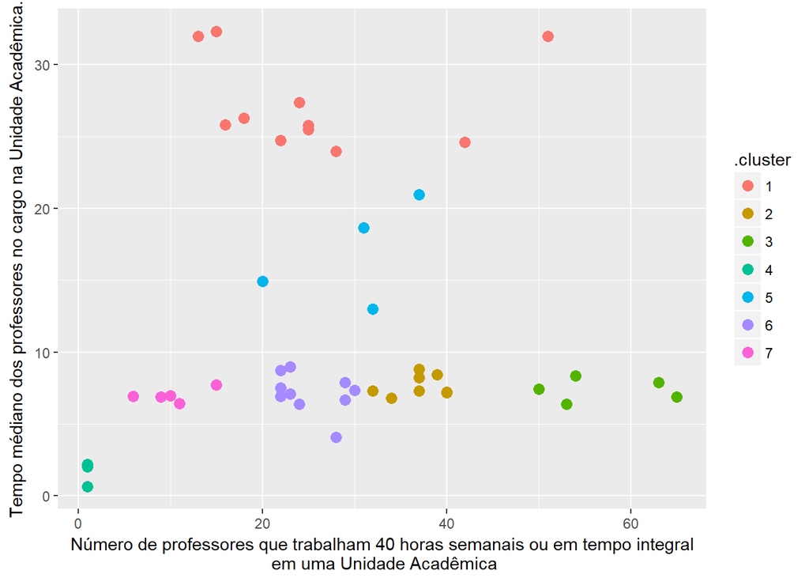

```r
data_t = dados_ufcg %>%
    mutate(`Professor 40h ou DE` = log10(`Professor 40h ou DE`)) %>%
    mutate_each(funs(as.vector(scale(.))), `Professor 40h ou DE`, idade_mediana)

data = tibble(k = 1:7) %>%
  group_by(k) %>%
  do(kmeans(select(data_t, idade_mediana, `Professor 40h ou DE`), #Junção dos professores com 40 horas
                                                                  #que tem dedicação exclusiva ou não a ufcg.
            centers = .$k,
            nstart = 1) %>% augment(dados_ufcg))
data %>%
  ggplot(aes(y = idade_mediana, x = `Professor.40h.ou.DE`, colour = .cluster)) +
  geom_point(size = 3) +
  labs(
    x="Número de professores que trabalham 40 horas semanais ou em tempo integral\n em uma Unidade Acadêmica",
    y="Tempo médiano dos professores no cargo na Unidade Acadêmica."
  )
```

```r
htmltools::includeHTML("./footer.html")
```

**Resultados:**